# Analyzing the Reptile data for State of Nature Report 2023

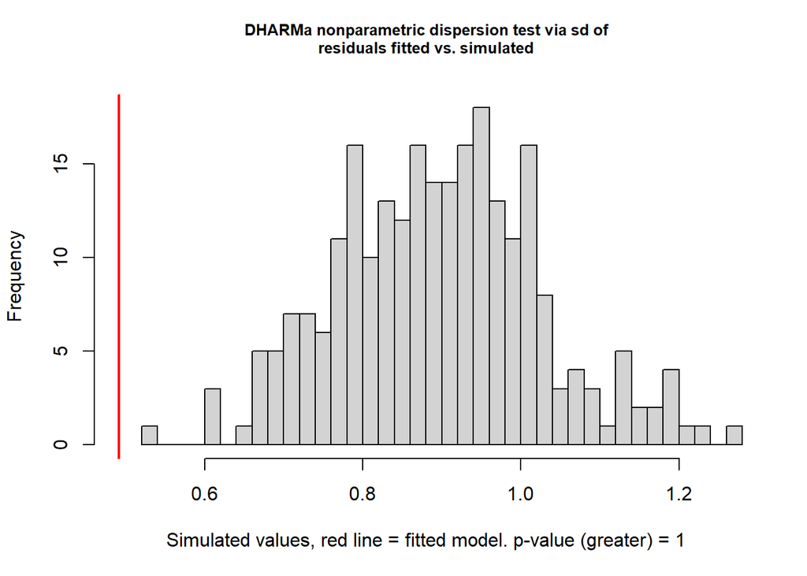

```
##
##  DHARMa nonparametric dispersion test via sd of residuals fitted vs.
##  simulated
##
## data:  simulationOutput
## dispersion = 0.548, p-value = 1
## alternative hypothesis: greater
```

```r
testDispersion(loess.sp.rich.sim.res, alternative = 'greater') # p-value = 1, no over-dispersion
```

```r
testDispersion(loess.sp.rich.sim.res, alternative = 'less', plot = F) # p < 2.2e-16 -> under-dispersion
```

```
##
##  DHARMa nonparametric dispersion test via sd of residuals fitted vs.
##  simulated
##
## data:  simulationOutput
## dispersion = 0.548, p-value < 2.2e-16
## alternative hypothesis: less
```

```r
testDispersion(loess.sp.rich.sim.res, alternative = 'greater') # p = 1, suggesting under-dispersion
```

```
##
##  DHARMa nonparametric dispersion test via sd of residuals fitted vs.
##  simulated
##
## data:  simulationOutput
## dispersion = 0.548, p-value = 1
## alternative hypothesis: greater
```

```r
testDispersion(loess.sp.rich.sim.res, alternative = 'less', plot = F) # p < 2.2e-16 -> under-dispersion, small power
```

```
##
##  DHARMa nonparametric dispersion test via sd of residuals fitted vs.
##  simulated
##
## data:  simulationOutput
## dispersion = 0.548, p-value < 2.2e-16
## alternative hypothesis: less
```

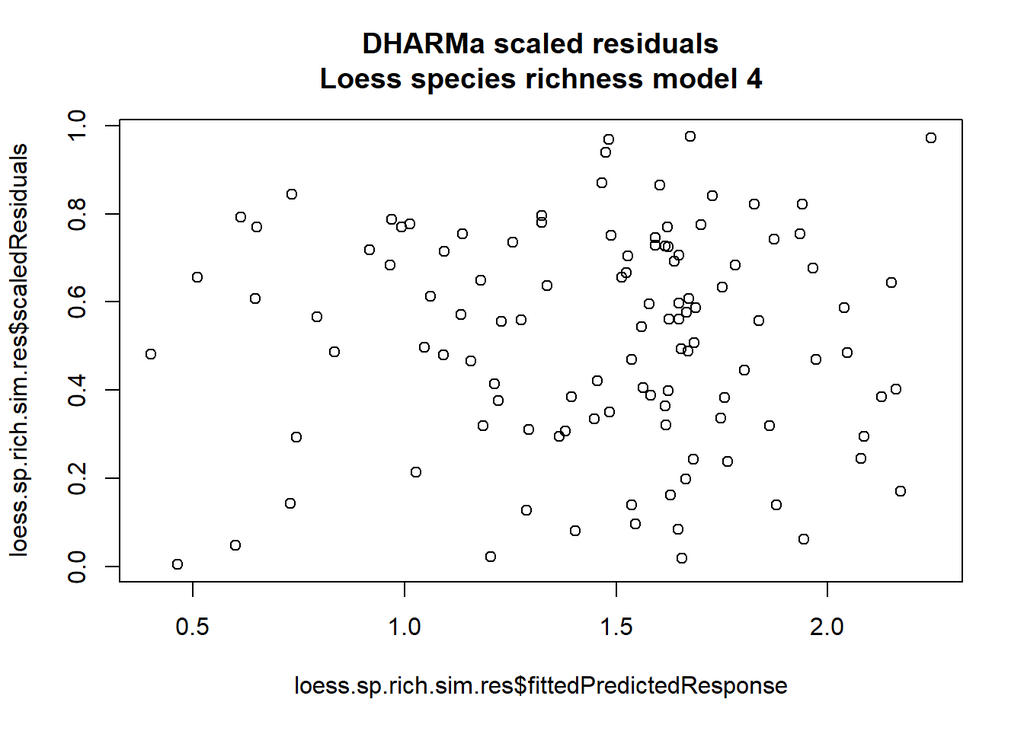

```r
plot(loess.sp.rich.sim.res$fittedPredictedResponse, loess.sp.rich.sim.res$scaledResiduals, main = 'DHARMa scaled residuals\nLoess species richness model 4')
```

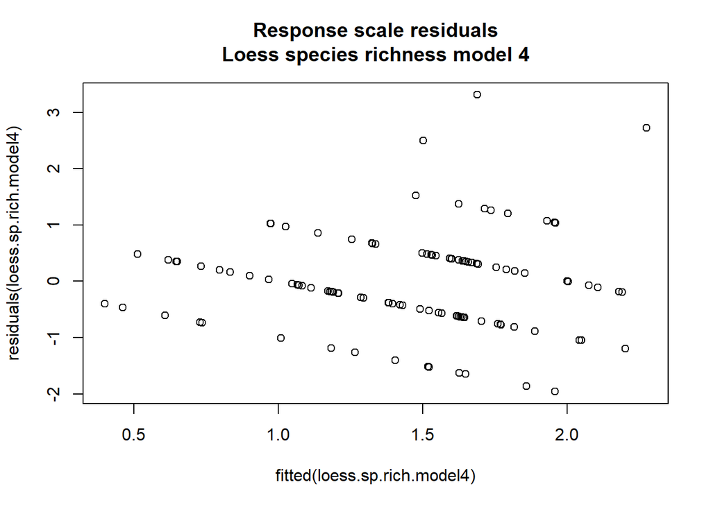

```r
plot(fitted(loess.sp.rich.model4), residuals(loess.sp.rich.model4), main = 'Response scale residuals\nLoess species richness model 4')
```

We can see clear indications of under-dispersion because the results of the testDispersion functions with the alternative of lower dispersion are highly significant. This means we have lower statistical power (increased type II error rate). In addition we see that there are some over-predictions for the seasonal and diel predictors. However, as none of the research hypotheses predictors were included in the final model, we will not try to predict species richness in the Loess anyway. Back up all the Loess species richness models and document the model selection process:

```r
# for (model in c(ls()[grep('*loess.sp.rich.model', ls())])){
#   capture.output(cat(model), cat('\n=========\n'), summary(get(model)), cat('\n=========\n'),
#                  file = '../output/Loess - species richness model selection.txt', append = T)
# }
#
# save(list = ls()[grep('*loess.sp.rich.model', ls())], file = '../output/Inner sands - Species richness models.Rdata')
# capture.output(cat('The best fitting model for species richness in the loess is loess.sp.rich.model4.'),
#                summary(loess.sp.rich.model4), file = '../output/Loess species richness - best fitting model.txt', append = F)

# Create a table comparing total abundance models:
for(model in ls()[grep('*loess.sp.rich.model.', ls())]){
  sp.rich.comparison <- rbind(sp.rich.comparison,
                              data.table(unit = 'Loess', model = model,
                                         no.of.preds = length(attr(get(model)$modelInfo$terms$cond$fixed, 'term.labels')),
                                         AIC = AIC(get(model)), BIC = BIC(get(model)),
                                         data = as.character(get(model)$call$data),
                                         family = as.character(get(model)$call$family),
                                         formula = as.character(get(model)$call$formula)))
}
sp.rich.comparison <- sp.rich.comparison[!(formula %like% '~' | formula %like% 'species.richness')] # remove redundant rows
sp.rich.comparison <- unique(sp.rich.comparison)
setorder(sp.rich.comparison, unit, AIC)  # Sort by AIC (ascending)
sp.rich.comparison[unit == 'Loess', .(model, family, no.of.preds, AIC, BIC)] # View the table
```

```
##                               model  family no.of.preds      AIC      BIC
##                              <char>  <char>       <num>    <num>    <num>
## 1:             loess.sp.rich.model3 poisson           4 307.8939 324.2049
## 2:             loess.sp.rich.model4 poisson           3 309.0570 322.6495
## 3:             loess.sp.rich.model2 poisson           5 309.2320 328.2615
## 4:             loess.sp.rich.model1 poisson           6 312.2518 336.7183
## 5: loess.sp.rich.model.full.Poisson poisson           7 314.2599 344.1634
```

```r
rm(list = setdiff(ls()[grep('*loess.sp.rich.model', ls())], c('loess.sp.rich.model4'))) # Clean up
```

Again, we find no researcher hypotheses in the chosen model, so we do not explore its predictions. Move on to total reptile abundance. Let’s start with data visualization:

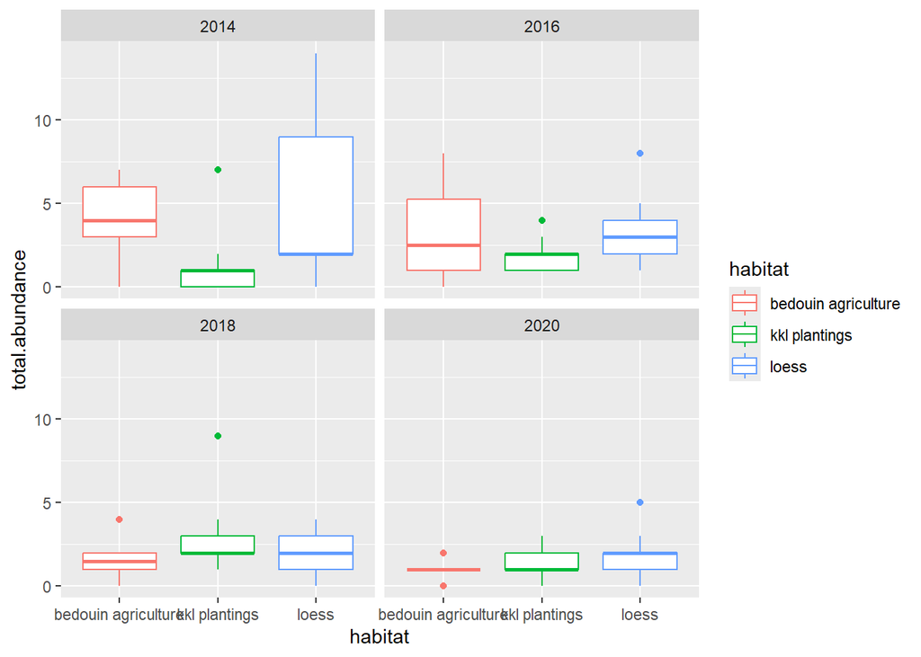

```r
ggplot(data = loess, aes(x = habitat, y = total.abundance, color = habitat)) + geom_boxplot() + facet_wrap(. ~ year)
```

2018-2020 seem lower than 2014-2016, but not in KKL (JNF) plantations. Let’s examine the histogram of the total abundance of all Loess surveys:

```r
loess[, .(no.of.surveys = uniqueN(survey_ID)), keyby = total.abundance]
```

```
## Key: <total.abundance>
##     total.abundance no.of.surveys
##               <num>         <int>
##  1:               0            15
##  2:               1            29
##  3:               2            32
##  4:               3             9
##  5:               4            10
##  6:               5             5
##  7:               6             4
##  8:               7             2
##  9:               8             2
## 10:               9             2
## 11:              12             1
## 12:              14             1
```

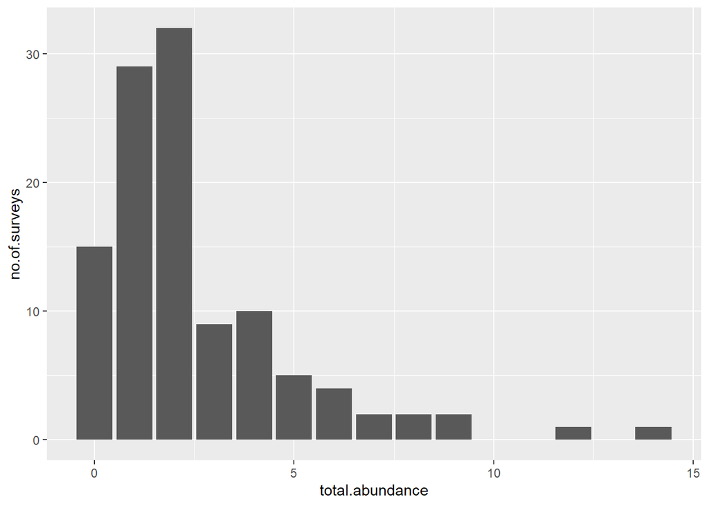

```r
ggplot(loess[, .(no.of.surveys = uniqueN(survey_ID)), keyby = total.abundance], aes(x = total.abundance, y = no.of.surveys)) + geom_col()
```

The distribution is obviously skewed, with many low (0-2) values. Let’s see when the surveys were taken, both in season and in the time of day. First, view the season of the survey:

```r
loess[, .(no.of.surveys = uniqueN(survey_ID)), keyby = month(Date)] # From April to July, mostly in June
```

```
## Key: <month>
##    month no.of.surveys
##    <int>         <int>
## 1:     4            10
## 2:     5            31
## 3:     6            49
## 4:     7            22
```

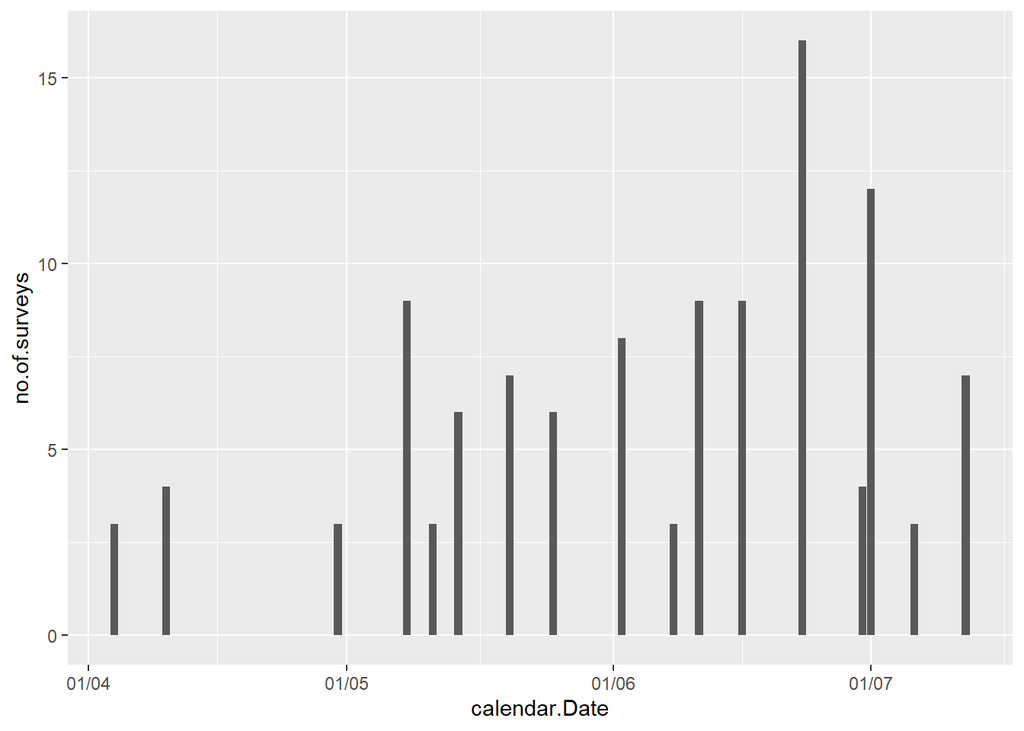

```r
ggplot(loess[, .(no.of.surveys = uniqueN(survey_ID)), keyby = .(calendar.Date = as.Date(yday(Date)-1))], aes(x = calendar.Date, y = no.of.surveys)) + geom_col() + scale_x_date(date_labels = '%d/%m')
```

```r
reptiles[unit %like% 'Loess', .(no.of.surveys = uniqueN(survey_ID)), keyby = round(ITime)] # From 7:00 to 18:00, mostly in 10:00-12:00
```

```
## Key: <round>
##        round no.of.surveys
##      <ITime>         <int>
##  1: 07:00:00             3
##  2: 08:00:00             3
##  3: 09:00:00             9
##  4: 10:00:00            23
##  5: 11:00:00            14
##  6: 12:00:00            21
##  7: 13:00:00            13
##  8: 14:00:00             8
##  9: 15:00:00             8
## 10: 16:00:00             6
## 11: 17:00:00             3
## 12: 18:00:00             1
```

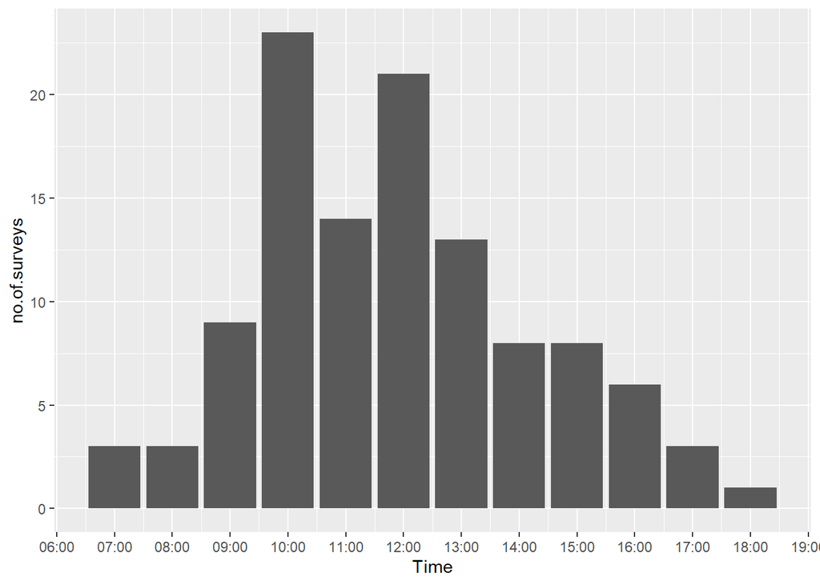

```r
ggplot(reptiles[unit %like% 'Loess', .(no.of.surveys = uniqueN(survey_ID)), keyby = .(Time = as.POSIXct(round(ITime)))], aes(x = Time, y = no.of.surveys)) + geom_col() + scale_x_datetime(date_labels = '%H:%M', date_breaks = '1 hour')
```

While surveys were conducted from 7:00 to 18:00, most of them were conducted in 10:00 to 12:00. Let’s proceed to model selection:

```r
# Full model, Poisson response
loess.abnd.model.full.Poisson <- glmmTMB(total.abundance ~ year.count * habitat + sin.dist.21.June + cos.dist.21.June +
                                   sin.dist.noon + cos.dist.noon + (1|site), family = 'poisson', data = loess)
summary(loess.abnd.model.full.Poisson) # AIC = 440.2 BIC = 470.1. Trend-habitat interactions are significant
```

```
##  Family: poisson  ( log )
## Formula:
## total.abundance ~ year.count * habitat + sin.dist.21.June + cos.dist.21.June +
##     sin.dist.noon + cos.dist.noon + (1 | site)
## Data: loess
##
##      AIC      BIC   logLik deviance df.resid
##    440.2    470.1   -209.1    418.2      101
##
## Random effects:
##
## Conditional model:
##  Groups Name        Variance Std.Dev.
##  site   (Intercept) 0.01998  0.1414
## Number of obs: 112, groups:  site, 7
##
## Conditional model:
##                                 Estimate Std. Error z value Pr(>|z|)
## (Intercept)                      3.37729    0.66780   5.057 4.25e-07 ***
## year.count                      -0.25511    0.06613  -3.858 0.000114 ***
## habitatkkl plantings            -0.96863    0.28199  -3.435 0.000593 ***
## habitatloess                    -0.12713    0.27252  -0.466 0.640861
## sin.dist.21.June                 1.03156    0.33372   3.091 0.001994 **
## cos.dist.21.June                -2.64180    0.70493  -3.748 0.000179 ***
## sin.dist.noon                    0.47348    0.16469   2.875 0.004040 **
## cos.dist.noon                    0.77682    0.38156   2.036 0.041761 *
## year.count:habitatkkl plantings  0.29139    0.08417   3.462 0.000536 ***
## year.count:habitatloess          0.13216    0.07856   1.682 0.092515 .
## ---
## Signif. codes:  0 '***' 0.001 '**' 0.01 '*' 0.05 '.' 0.1 ' ' 1
```

```r
cat('PHI = '); deviance(loess.abnd.model.full.Poisson)/df.residual(loess.abnd.model.full.Poisson)
```

```
## PHI =
```

```
## [1] 1.441331
```

```r
drop1(loess.abnd.model.full.Poisson)
```

```
## Single term deletions
##
## Model:
## total.abundance ~ year.count * habitat + sin.dist.21.June + cos.dist.21.June +
##     sin.dist.noon + cos.dist.noon + (1 | site)
##                    Df    AIC
## <none>                440.25
## sin.dist.21.June    1 447.18
## cos.dist.21.June    1 451.26
## sin.dist.noon       1 446.78
## cos.dist.noon       1 442.66
## year.count:habitat  2 449.08
```

This time PHI > 1, so we should try a negative binomial model as well.

```r
# Full model, Negative Binomial response
loess.abnd.model.full.NB <- glmmTMB(total.abundance ~ year.count * habitat + sin.dist.21.June + cos.dist.21.June +
                                   sin.dist.noon + cos.dist.noon + (1|site), family = 'nbinom2', data = loess)
summary(loess.abnd.model.full.NB)
```

```
##  Family: nbinom2  ( log )
## Formula:
## total.abundance ~ year.count * habitat + sin.dist.21.June + cos.dist.21.June +
##     sin.dist.noon + cos.dist.noon + (1 | site)
## Data: loess
##
##      AIC      BIC   logLik deviance df.resid
##    434.6    467.2   -205.3    410.6      100
##
## Random effects:
##
## Conditional model:
##  Groups Name        Variance Std.Dev.
##  site   (Intercept) 0.008345 0.09135
## Number of obs: 112, groups:  site, 7
##
## Dispersion parameter for nbinom2 family (): 6.96
##
## Conditional model:
##                                 Estimate Std. Error z value Pr(>|z|)
## (Intercept)                      3.21202    0.75734   4.241 2.22e-05 ***
## year.count                      -0.24626    0.07228  -3.407 0.000657 ***
## habitatkkl plantings            -0.97959    0.32220  -3.040 0.002363 **
## habitatloess                    -0.05256    0.30863  -0.170 0.864766
## sin.dist.21.June                 1.06090    0.38558   2.751 0.005934 **
## cos.dist.21.June                -2.67408    0.80611  -3.317 0.000909 ***
## sin.dist.noon                    0.45723    0.19317   2.367 0.017931 *
## cos.dist.noon                    0.96736    0.44740   2.162 0.030606 *
## year.count:habitatkkl plantings  0.29429    0.09379   3.138 0.001702 **
## year.count:habitatloess          0.13019    0.08796   1.480 0.138828
## ---
## Signif. codes:  0 '***' 0.001 '**' 0.01 '*' 0.05 '.' 0.1 ' ' 1
```

```r
drop1(loess.abnd.model.full.NB)
```

```
## Single term deletions
##
## Model:
## total.abundance ~ year.count * habitat + sin.dist.21.June + cos.dist.21.June +
##     sin.dist.noon + cos.dist.noon + (1 | site)
##                    Df    AIC
## <none>                434.61
## sin.dist.21.June    1 439.72
## cos.dist.21.June    1 442.85
## sin.dist.noon       1 438.16
## cos.dist.noon       1 437.64
## year.count:habitat  2 440.69
```

Apparently, we cannot drop any predictors to decrease AIC, but we will try to do so anyway. Let’s start by dropping the interaction:

```r
loess.abnd.model1 <- glmmTMB(total.abundance ~ year.count + habitat + sin.dist.21.June + cos.dist.21.June +
                                   sin.dist.noon + cos.dist.noon + (1|site), family = 'nbinom2', data = loess)
summary(loess.abnd.model1)
```

```
##  Family: nbinom2  ( log )
## Formula:
## total.abundance ~ year.count + habitat + sin.dist.21.June + cos.dist.21.June +
##     sin.dist.noon + cos.dist.noon + (1 | site)
## Data: loess
##
##      AIC      BIC   logLik deviance df.resid
##    440.7    467.9   -210.3    420.7      102
##
## Random effects:
##
## Conditional model:
##  Groups Name        Variance Std.Dev.
##  site   (Intercept) 0.01509  0.1228
## Number of obs: 112, groups:  site, 7
##
## Dispersion parameter for nbinom2 family (): 5.53
##
## Conditional model:
##                      Estimate Std. Error z value Pr(>|z|)
## (Intercept)           2.88646    0.74326   3.883 0.000103 ***
## year.count           -0.10408    0.04049  -2.571 0.010154 *
## habitatkkl plantings -0.22327    0.22421  -0.996 0.319348
## habitatloess          0.19676    0.25082   0.784 0.432779
## sin.dist.21.June      1.03668    0.40476   2.561 0.010431 *
## cos.dist.21.June     -2.44195    0.81388  -3.000 0.002696 **
## sin.dist.noon         0.44637    0.19386   2.303 0.021304 *
## cos.dist.noon         0.73928    0.44003   1.680 0.092942 .
## ---
## Signif. codes:  0 '***' 0.001 '**' 0.01 '*' 0.05 '.' 0.1 ' ' 1
```

```r
drop1(loess.abnd.model1)
```

```
## Single term deletions
##
## Model:
## total.abundance ~ year.count + habitat + sin.dist.21.June + cos.dist.21.June +
##     sin.dist.noon + cos.dist.noon + (1 | site)
##                  Df    AIC
## <none>              440.69
## year.count        1 445.19
## habitat           2 440.65
## sin.dist.21.June  1 444.97
## cos.dist.21.June  1 447.25
## sin.dist.noon     1 443.94
## cos.dist.noon     1 441.65
```

Proceed to dropping the habitat:

```r
loess.abnd.model2 <- glmmTMB(total.abundance ~ year.count + sin.dist.21.June + cos.dist.21.June +
                                   sin.dist.noon + cos.dist.noon + (1|site), family = 'nbinom2', data = loess)
summary(loess.abnd.model2)
```

```
##  Family: nbinom2  ( log )
## Formula:
## total.abundance ~ year.count + sin.dist.21.June + cos.dist.21.June +
##     sin.dist.noon + cos.dist.noon + (1 | site)
## Data: loess
##
##      AIC      BIC   logLik deviance df.resid
##    440.6    462.4   -212.3    424.6      104
##
## Random effects:
##
## Conditional model:
##  Groups Name        Variance Std.Dev.
##  site   (Intercept) 0.034    0.1844
## Number of obs: 112, groups:  site, 7
##
## Dispersion parameter for nbinom2 family (): 5.27
##
## Conditional model:
##                  Estimate Std. Error z value Pr(>|z|)
## (Intercept)       3.03277    0.76815   3.948 7.88e-05 ***
## year.count       -0.10526    0.04085  -2.577  0.00997 **
## sin.dist.21.June  1.05036    0.39873   2.634  0.00843 **
## cos.dist.21.June -2.43741    0.82876  -2.941  0.00327 **
## sin.dist.noon     0.47525    0.18369   2.587  0.00968 **
## cos.dist.noon     0.57006    0.43498   1.311  0.19001
## ---
## Signif. codes:  0 '***' 0.001 '**' 0.01 '*' 0.05 '.' 0.1 ' ' 1
```

```r
drop1(loess.abnd.model2)
```

```
## Single term deletions
##
## Model:
## total.abundance ~ year.count + sin.dist.21.June + cos.dist.21.June +
##     sin.dist.noon + cos.dist.noon + (1 | site)
##                  Df    AIC
## <none>              440.65
## year.count        1 445.22
## sin.dist.21.June  1 445.44
## cos.dist.21.June  1 447.02
## sin.dist.noon     1 445.13
## cos.dist.noon     1 440.44
```

We can drop cosine diel pattern:

```r
loess.abnd.model3 <- glmmTMB(total.abundance ~ year.count + sin.dist.21.June + cos.dist.21.June +
                                   sin.dist.noon + (1|site), family = 'nbinom2', data = loess)
summary(loess.abnd.model3)
```

```
##  Family: nbinom2  ( log )
## Formula:
## total.abundance ~ year.count + sin.dist.21.June + cos.dist.21.June +
##     sin.dist.noon + (1 | site)
## Data: loess
##
##      AIC      BIC   logLik deviance df.resid
##    440.4    459.5   -213.2    426.4      105
##
## Random effects:
##
## Conditional model:
##  Groups Name        Variance Std.Dev.
##  site   (Intercept) 0.02756  0.166
## Number of obs: 112, groups:  site, 7
##
## Dispersion parameter for nbinom2 family (): 5.25
##
## Conditional model:
##                  Estimate Std. Error z value Pr(>|z|)
## (Intercept)       3.24730    0.74267   4.372 1.23e-05 ***
## year.count       -0.11255    0.04034  -2.790  0.00527 **
## sin.dist.21.June  0.96440    0.38865   2.481  0.01309 *
## cos.dist.21.June -2.13790    0.78662  -2.718  0.00657 **
## sin.dist.noon     0.45975    0.17886   2.570  0.01016 *
## ---
## Signif. codes:  0 '***' 0.001 '**' 0.01 '*' 0.05 '.' 0.1 ' ' 1
```

```r
drop1(loess.abnd.model3)
```

```
## Single term deletions
##
## Model:
## total.abundance ~ year.count + sin.dist.21.June + cos.dist.21.June +
##     sin.dist.noon + (1 | site)
##                  Df    AIC
## <none>              440.44
## year.count        1 446.12
## sin.dist.21.June  1 444.41
## cos.dist.21.June  1 445.44
## sin.dist.noon     1 444.80
```

No more predictors to drop, and the full model is still preferable according to AIC. At least we tried! Let’s proceed to model diagnostics:

```r
# The chosen model is the full negative binomial model....
summary(loess.abnd.model.full.NB)
```

```
##  Family: nbinom2  ( log )
## Formula:
## total.abundance ~ year.count * habitat + sin.dist.21.June + cos.dist.21.June +
##     sin.dist.noon + cos.dist.noon + (1 | site)
## Data: loess
##
##      AIC      BIC   logLik deviance df.resid
##    434.6    467.2   -205.3    410.6      100
##
## Random effects:
##
## Conditional model:
##  Groups Name        Variance Std.Dev.
##  site   (Intercept) 0.008345 0.09135
## Number of obs: 112, groups:  site, 7
##
## Dispersion parameter for nbinom2 family (): 6.96
##
## Conditional model:
##                                 Estimate Std. Error z value Pr(>|z|)
## (Intercept)                      3.21202    0.75734   4.241 2.22e-05 ***
## year.count                      -0.24626    0.07228  -3.407 0.000657 ***
## habitatkkl plantings            -0.97959    0.32220  -3.040 0.002363 **
## habitatloess                    -0.05256    0.30863  -0.170 0.864766
## sin.dist.21.June                 1.06090    0.38558   2.751 0.005934 **
## cos.dist.21.June                -2.67408    0.80611  -3.317 0.000909 ***
## sin.dist.noon                    0.45723    0.19317   2.367 0.017931 *
## cos.dist.noon                    0.96736    0.44740   2.162 0.030606 *
## year.count:habitatkkl plantings  0.29429    0.09379   3.138 0.001702 **
## year.count:habitatloess          0.13019    0.08796   1.480 0.138828
## ---
## Signif. codes:  0 '***' 0.001 '**' 0.01 '*' 0.05 '.' 0.1 ' ' 1
```

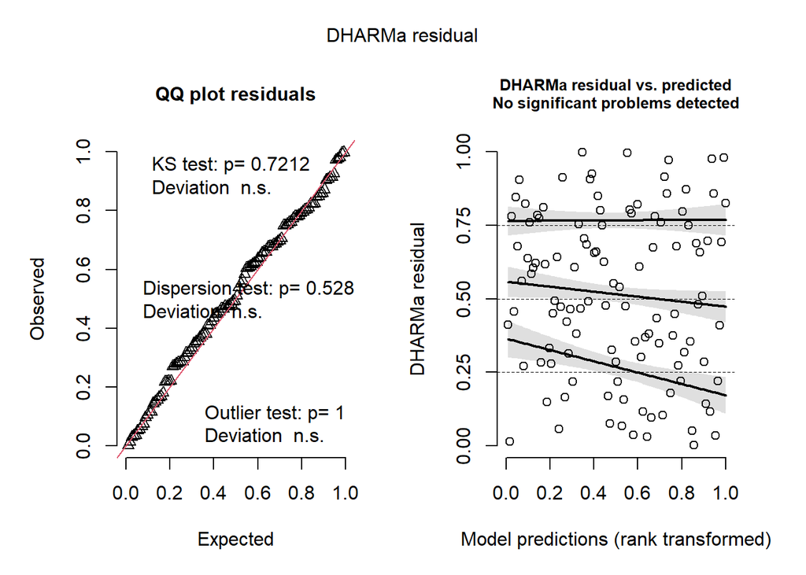

```r
loess.abnd.sim.res <- simulateResiduals(loess.abnd.model.full.NB)
plot(loess.abnd.sim.res) # No problems detected in the QQ plot
```

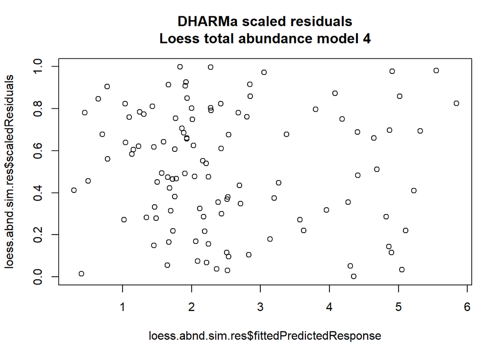

```r
plot(loess.abnd.sim.res$fittedPredictedResponse, loess.abnd.sim.res$scaledResiduals, main = 'DHARMa scaled residuals\nLoess total abundance model 4')
```

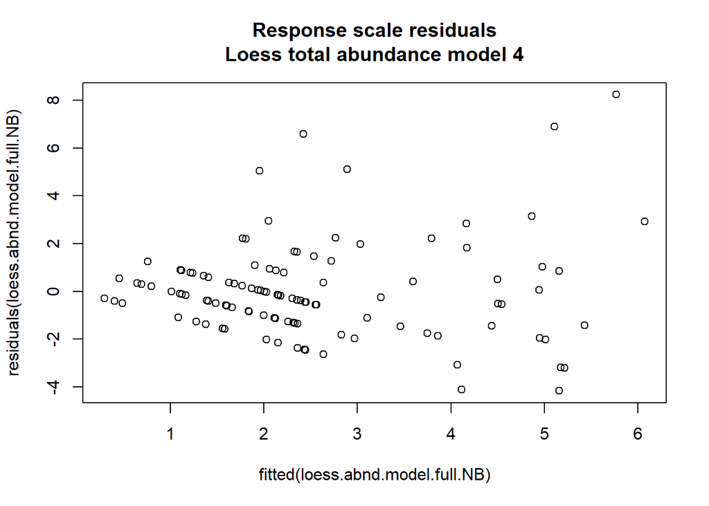

```r
plot(fitted(loess.abnd.model.full.NB), residuals(loess.abnd.model.full.NB), main = 'Response scale residuals\nLoess total abundance model 4')
```

Back up and document all the Loess total abundance models:

```r
# for (model in c(ls()[grep('*loess.sp.rich.model', ls())])){
#   capture.output(cat(model), cat('\n=========\n'), summary(get(model)), cat('\n=========\n'),
#                  file = '../output/Loess - total abundance model selection.txt', append = T)
# }
#
# save(list = ls()[grep('*loess.abnd.model', ls())], file = '../output/Loess - total abundance models.Rdata')
# capture.output(cat('The best fitting model for total abundance in the loess is loess.abnd.model.full.NB.'),
#                summary(loess.abnd.model.full.NB), file = '../output/Loess total abundance - best fitting model.txt', append = F)

# Create a table comparing total abundance models:
for(model in ls()[grep('*loess.abnd.model.', ls())]){
  total.abnd.comparison <- rbind(total.abnd.comparison,
                              data.table(unit = 'Loess', model = model,
                                         no.of.preds = length(attr(get(model)$modelInfo$terms$cond$fixed, 'term.labels')),
                                         AIC = AIC(get(model)), BIC = BIC(get(model)),
                                         data = as.character(get(model)$call$data),
                                         family = as.character(get(model)$call$family),
                                         formula = as.character(get(model)$call$formula)))
}
total.abnd.comparison <- total.abnd.comparison[!(formula %like% '~' | formula %like% 'total.abundance')] # remove redundant rows
total.abnd.comparison <- unique(total.abnd.comparison)
setorder(total.abnd.comparison, unit, AIC)  # Sort by AIC (ascending)
total.abnd.comparison[unit == 'Loess', .(model, family, formula, no.of.preds, AIC, BIC)] # View the table
```

```
##                            model  family
##                           <char>  <char>
## 1:      loess.abnd.model.full.NB nbinom2
## 2: loess.abnd.model.full.Poisson poisson
## 3:             loess.abnd.model3 nbinom2
## 4:             loess.abnd.model2 nbinom2
## 5:             loess.abnd.model1 nbinom2
##                                                                                                    formula
##                                                                                                     <char>
## 1: year.count * habitat + sin.dist.21.June + cos.dist.21.June + sin.dist.noon + cos.dist.noon + (1 | site)
## 2: year.count * habitat + sin.dist.21.June + cos.dist.21.June + sin.dist.noon + cos.dist.noon + (1 | site)
## 3:                           year.count + sin.dist.21.June + cos.dist.21.June + sin.dist.noon + (1 | site)
## 4:           year.count + sin.dist.21.June + cos.dist.21.June + sin.dist.noon + cos.dist.noon + (1 | site)
## 5: year.count + habitat + sin.dist.21.June + cos.dist.21.June + sin.dist.noon + cos.dist.noon + (1 | site)
##    no.of.preds      AIC      BIC
##          <num>    <num>    <num>
## 1:           7 434.6130 467.2350
## 2:           7 440.2454 470.1489
## 3:           4 440.4351 459.4646
## 4:           5 440.6480 462.3960
## 5:           6 440.6873 467.8723
```

```r
rm(list = setdiff(ls()[grep('*loess.abnd.model', ls())], c('loess.abnd.model.full.NB'))) # Clean up
```

This time we have surprisingly accepted the full model. Let’s see what are the trends in each land use:

```r
EMM_year_count <- emtrends(object = loess.abnd.model.full.NB, specs = 'habitat', var = 'year.count', type = 'response')
test_results_land_use <- test(EMM_year_count, null = 0, adjust="fdr")
print(test_results_land_use)
```

```
##  habitat             year.count.trend     SE  df z.ratio p.value
##  bedouin agriculture           -0.246 0.0723 Inf  -3.407  0.0020
##  kkl plantings                  0.048 0.0671 Inf   0.716  0.4738
##  loess                         -0.116 0.0557 Inf  -2.085  0.0556
##
## P value adjustment: fdr method for 3 tests
```

So, this mean that there is a significant (p = 0.0020) negative trend in the bedouin agriculture, but no significant trend in KKL plantings or the natural loess. Now let’s proceed to examining the statistical significance of the overall trend (giving equal weight to each land use category):

```r
test_results_year_ct_overall <- contrast(object = EMM_year_count, method = list(mean_trend = c(1/3, 1/3, 1/3)))
print(test_results_year_ct_overall)
```

```
##  contrast   estimate     SE  df z.ratio p.value
##  mean_trend   -0.105 0.0406 Inf  -2.579  0.0099
```

This means there is an overall significant negative trend in reptile abundance (p = 0.0099). Next, let’s see if there are significant differences between habitats (land uses):

```r
EMM <- emmeans(object = loess.abnd.model.full.NB, ~habitat * year.count)
test_results_land_use <- test(pairs(EMM, by = 'year.count'), by = NULL, adjust="fdr")
print(test_results_land_use)
```

```
##  contrast                            year.count estimate    SE  df z.ratio
##  bedouin agriculture - kkl plantings       2.98    0.102 0.219 Inf   0.466
##  bedouin agriculture - loess               2.98   -0.336 0.243 Inf  -1.379
##  kkl plantings - loess                     2.98   -0.438 0.203 Inf  -2.156
##  p.value
##   0.6413
##   0.2520
##   0.0934
##
## Results are given on the log (not the response) scale.
## P value adjustment: fdr method for 3 tests
```

We found no significant differences in total reptile abundance between habitats (p > 0.05 for all comparisons). Now let’s explore the model’s predictions:

```r
# Loess - predict reptile total abundance----
summary(loess.abnd.model.full.NB)
```

```
##  Family: nbinom2  ( log )
## Formula:
## total.abundance ~ year.count * habitat + sin.dist.21.June + cos.dist.21.June +
##     sin.dist.noon + cos.dist.noon + (1 | site)
## Data: loess
##
##      AIC      BIC   logLik deviance df.resid
##    434.6    467.2   -205.3    410.6      100
##
## Random effects:
##
## Conditional model:
##  Groups Name        Variance Std.Dev.
##  site   (Intercept) 0.008345 0.09135
## Number of obs: 112, groups:  site, 7
##
## Dispersion parameter for nbinom2 family (): 6.96
##
## Conditional model:
##                                 Estimate Std. Error z value Pr(>|z|)
## (Intercept)                      3.21202    0.75734   4.241 2.22e-05 ***
## year.count                      -0.24626    0.07228  -3.407 0.000657 ***
## habitatkkl plantings            -0.97959    0.32220  -3.040 0.002363 **
## habitatloess                    -0.05256    0.30863  -0.170 0.864766
## sin.dist.21.June                 1.06090    0.38558   2.751 0.005934 **
## cos.dist.21.June                -2.67408    0.80611  -3.317 0.000909 ***
## sin.dist.noon                    0.45723    0.19317   2.367 0.017931 *
## cos.dist.noon                    0.96736    0.44740   2.162 0.030606 *
## year.count:habitatkkl plantings  0.29429    0.09379   3.138 0.001702 **
## year.count:habitatloess          0.13019    0.08796   1.480 0.138828
## ---
## Signif. codes:  0 '***' 0.001 '**' 0.01 '*' 0.05 '.' 0.1 ' ' 1
```

```r
# Predict by the mean observed values of date and time of day
loess[, sort(unique(unit))]
```

```
## [1] Loess Covered Areas in the Northern Negev
## 5 Levels: Coastal Plain Sands ... Planted Conifer Forests
```

```r
# Create a table to be filled by a loop with predictor values to be used for predictions
loess[, sort(unique(year))] # 2014-2020
```

```
## [1] 2014 2016 2018 2020
```

```r
# Plot the model's diel pattern
loess.total.abnd.diel.pred <- data.table(expand.grid(Date = as.Date(c('2014-07-20', '2016-07-20', '2018-07-20', '2020-07-20')),
                                                            site = NA, habitat = loess[, unique(habitat)],
                                                            ITime = seq(as.ITime('00:00'), as.ITime('23:30'), by = 1800)))
loess.total.abnd.diel.pred[, ':=' (Date.time = as.POSIXct(paste(Date, ITime, tz = 'Asia/Jerusalem')))]
loess.total.abnd.diel.pred[, .(Date,  ITime, Date.time)] # seems ok
```

```
##            Date    ITime           Date.time
##          <Date>  <ITime>              <POSc>
##   1: 2014-07-20 00:00:00 2014-07-20 00:00:00
##   2: 2016-07-20 00:00:00 2016-07-20 00:00:00
##   3: 2018-07-20 00:00:00 2018-07-20 00:00:00
##   4: 2020-07-20 00:00:00 2020-07-20 00:00:00
##   5: 2014-07-20 00:00:00 2014-07-20 00:00:00
##  ---
## 572: 2020-07-20 23:30:00 2020-07-20 23:30:00
## 573: 2014-07-20 23:30:00 2014-07-20 23:30:00
## 574: 2016-07-20 23:30:00 2016-07-20 23:30:00
## 575: 2018-07-20 23:30:00 2018-07-20 23:30:00
## 576: 2020-07-20 23:30:00 2020-07-20 23:30:00
```

```r
loess.total.abnd.diel.pred[, ':=' (dist.21.June = ifelse(yday(Date) < 354,
                                                                Date - as.Date(paste(year(Date), 6, 21, sep = '-')),
                                                                Date - as.Date(paste(year(Date) + 1, 6, 21, sep = '-'))),
                                          dist.noon = ifelse(as.ITime(ITime) < as.ITime('12:00'), # If the starting hour is before noon...
                                                             Date.time %--% as.POSIXct(paste(Date, '12:00:00'), tz = 'Asia/Jerusalem'), # ...then take the distance from today's noon
                                                             Date.time %--% as.POSIXct(paste(Date , '12:00:00'), tz = 'Asia/Jerusalem')))] # else, take the distance from tomorrow's noon

loess.total.abnd.diel.pred[, ':=' (year = year(Date),
                                          dist.21.June.radians = dist.21.June * pi / 182.5, # Convert to radians (multiply by pi and divide by half the number of days in a year), one harmonic
                                          dist.21.June.radians.2h = 2*dist.21.June * pi / 182.5,
                                          dist.noon.radians = dist.noon * pi/(12*60*60))] # convert to radians (multiply by pi and divide by half the number of seconds in a day), one harmonic
setorder(loess.total.abnd.diel.pred, Date, dist.21.June.radians, dist.noon.radians)
# View(loess.total.abnd.diel.pred) # seems ok
loess.total.abnd.diel.pred[, ':=' (year.count = year - min(year),
                                          sin.dist.21.June = sin(dist.21.June.radians), cos.dist.21.June = cos(dist.21.June.radians),
                                          sin.dist.noon = sin(dist.noon.radians), cos.dist.noon = cos(dist.noon.radians))] # Calculate the sin and cosine of the distance from June 21st
loess.total.abnd.diel.pred
```

```
##            Date   site             habitat    ITime           Date.time
##          <Date> <lgcl>              <fctr>  <ITime>              <POSc>
##   1: 2014-07-20     NA bedouin agriculture 23:30:00 2014-07-20 23:30:00
##   2: 2014-07-20     NA       kkl plantings 23:30:00 2014-07-20 23:30:00
##   3: 2014-07-20     NA               loess 23:30:00 2014-07-20 23:30:00
##   4: 2014-07-20     NA bedouin agriculture 23:00:00 2014-07-20 23:00:00
##   5: 2014-07-20     NA       kkl plantings 23:00:00 2014-07-20 23:00:00
##  ---
## 572: 2020-07-20     NA       kkl plantings 00:30:00 2020-07-20 00:30:00
## 573: 2020-07-20     NA               loess 00:30:00 2020-07-20 00:30:00
## 574: 2020-07-20     NA bedouin agriculture 00:00:00 2020-07-20 00:00:00
## 575: 2020-07-20     NA       kkl plantings 00:00:00 2020-07-20 00:00:00
## 576: 2020-07-20     NA               loess 00:00:00 2020-07-20 00:00:00
##      dist.21.June dist.noon  year dist.21.June.radians dist.21.June.radians.2h
##             <num>     <num> <int>                <num>                   <num>
```

[output cut: 37 more lines]

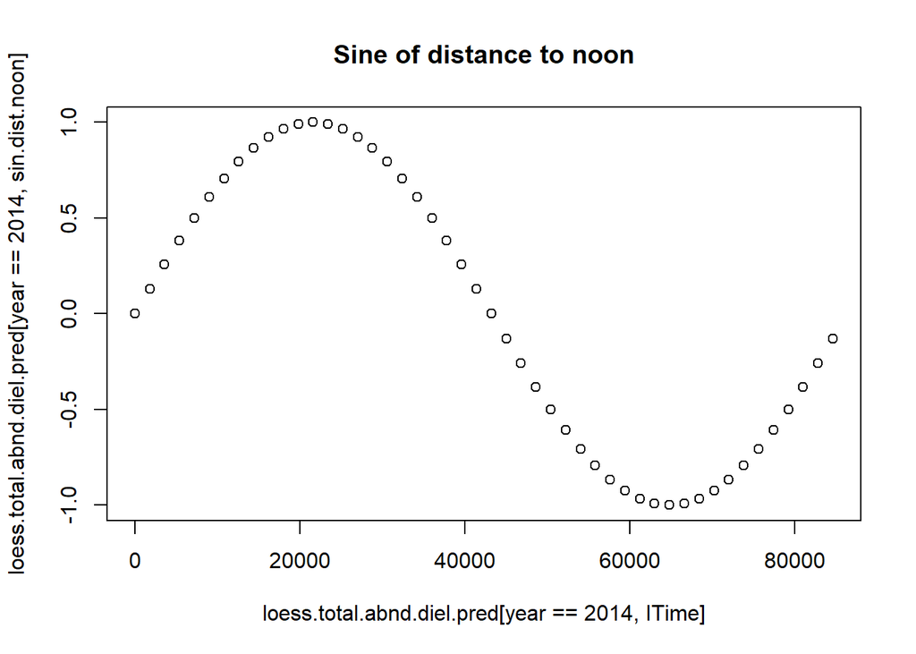

```r
plot(loess.total.abnd.diel.pred[year == 2014, ITime], loess.total.abnd.diel.pred[year == 2014,sin.dist.noon],
     main = 'Sine of distance to noon') # sanity check - should be a wave
```

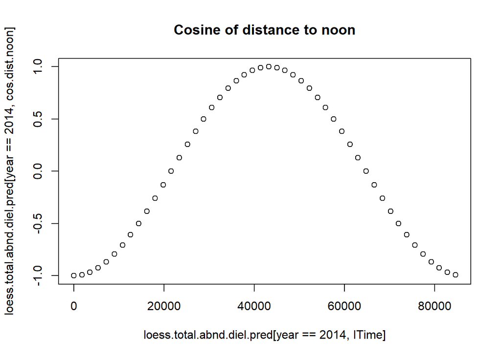

```r
plot(loess.total.abnd.diel.pred[year == 2014, ITime], loess.total.abnd.diel.pred[year == 2014, cos.dist.noon],
     main = 'Cosine of distance to noon') # sanity check - should be a wave
```

```r
bla <- predict(loess.abnd.model.full.NB, newdata = loess.total.abnd.diel.pred, type = 'response', se.fit = T)
loess.total.abnd.diel.pred[, ':=' (predicted.abnd = bla$fit, predicted.abnd.se = bla$se.fit)]
# loess.total.abnd.diel.pred[, .(year, predicted.abnd, predicted.abnd.se)] # From 12.1 in 2017 to 5.7 individuals in 2021 in both habitats
loess.total.abnd.diel.pred
```

```
## Index: <year>
##            Date   site             habitat    ITime           Date.time
##          <Date> <lgcl>              <fctr>  <ITime>              <POSc>
##   1: 2014-07-20     NA bedouin agriculture 23:30:00 2014-07-20 23:30:00
##   2: 2014-07-20     NA       kkl plantings 23:30:00 2014-07-20 23:30:00
##   3: 2014-07-20     NA               loess 23:30:00 2014-07-20 23:30:00
##   4: 2014-07-20     NA bedouin agriculture 23:00:00 2014-07-20 23:00:00
##   5: 2014-07-20     NA       kkl plantings 23:00:00 2014-07-20 23:00:00
##  ---
## 572: 2020-07-20     NA       kkl plantings 00:30:00 2020-07-20 00:30:00
## 573: 2020-07-20     NA               loess 00:30:00 2020-07-20 00:30:00
## 574: 2020-07-20     NA bedouin agriculture 00:00:00 2020-07-20 00:00:00
## 575: 2020-07-20     NA       kkl plantings 00:00:00 2020-07-20 00:00:00
## 576: 2020-07-20     NA               loess 00:00:00 2020-07-20 00:00:00
##      dist.21.June dist.noon  year dist.21.June.radians dist.21.June.radians.2h
```

[output cut: 38 more lines]

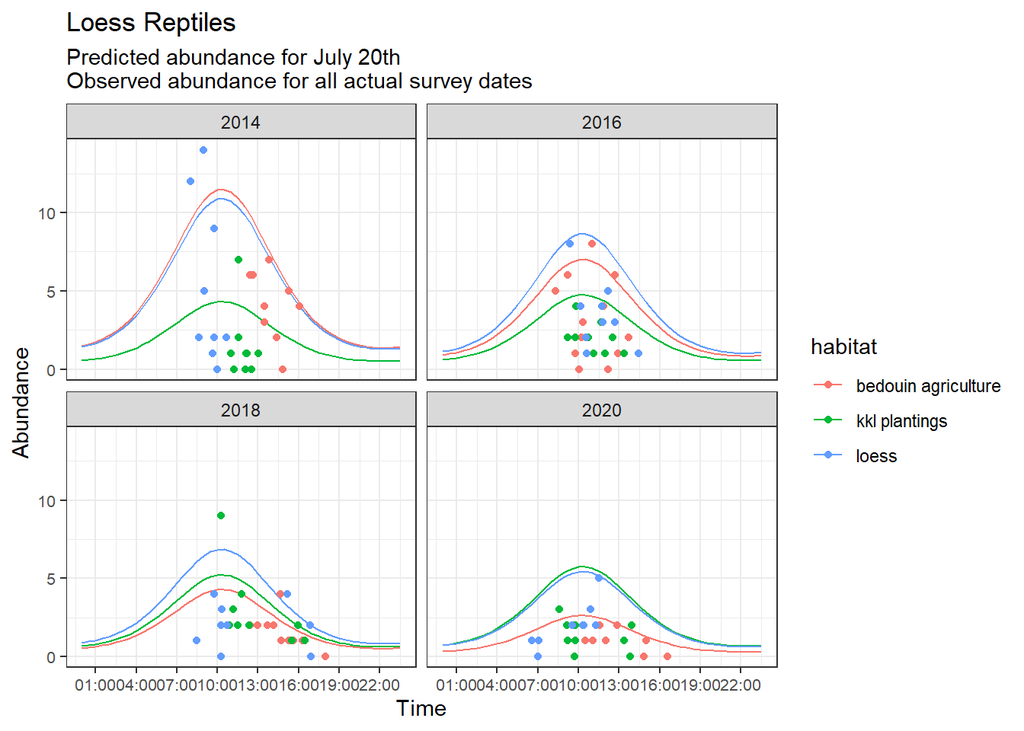

```r
# plot the diel predictions
ggplot(data = loess.total.abnd.diel.pred, aes(x = as.POSIXct(ITime), y = predicted.abnd, color = habitat)) + geom_line()  +
  geom_point(data = reptiles[unit %like% 'Loess', .(total.abnd = sum(count_individuals, na.rm = T)),
                             keyby = .(habitat, survey_ID, year(Date), ITime, as.POSIXct(paste(paste(2017, month(Date), mday(Date), sep = '-'), ITime),
                                                                                tz = 'Asia/Jerusalem'))],
             aes(x = as.POSIXct(ITime), y = total.abnd, color = habitat)) + labs(x = 'Time', y = 'Abundance', title = 'Loess Reptiles',
                                                                subtitle = 'Predicted abundance for July 20th\nObserved abundance for all actual survey dates') + theme_bw() +
  facet_wrap(. ~ year) + theme(axis.text = element_text(size = 8)) +
  scale_x_datetime(date_labels = '%H:%M', date_breaks = '3 hours')
```

The predictions are more or less in line the observations; peak time is around 10:30-11:00. Let’s proceed to predicting the trend, for a fixed calendar date (July 20th) and a fixed time of day (10:30 a.m.):

```r
summary(loess.abnd.model.full.NB)
```

```
##  Family: nbinom2  ( log )
## Formula:
## total.abundance ~ year.count * habitat + sin.dist.21.June + cos.dist.21.June +
##     sin.dist.noon + cos.dist.noon + (1 | site)
## Data: loess
##
##      AIC      BIC   logLik deviance df.resid
##    434.6    467.2   -205.3    410.6      100
##
## Random effects:
##
## Conditional model:
##  Groups Name        Variance Std.Dev.
##  site   (Intercept) 0.008345 0.09135
## Number of obs: 112, groups:  site, 7
##
## Dispersion parameter for nbinom2 family (): 6.96
##
## Conditional model:
##                                 Estimate Std. Error z value Pr(>|z|)
## (Intercept)                      3.21202    0.75734   4.241 2.22e-05 ***
## year.count                      -0.24626    0.07228  -3.407 0.000657 ***
## habitatkkl plantings            -0.97959    0.32220  -3.040 0.002363 **
## habitatloess                    -0.05256    0.30863  -0.170 0.864766
## sin.dist.21.June                 1.06090    0.38558   2.751 0.005934 **
## cos.dist.21.June                -2.67408    0.80611  -3.317 0.000909 ***
## sin.dist.noon                    0.45723    0.19317   2.367 0.017931 *
## cos.dist.noon                    0.96736    0.44740   2.162 0.030606 *
## year.count:habitatkkl plantings  0.29429    0.09379   3.138 0.001702 **
## year.count:habitatloess          0.13019    0.08796   1.480 0.138828
## ---
## Signif. codes:  0 '***' 0.001 '**' 0.01 '*' 0.05 '.' 0.1 ' ' 1
```

```r
loess.total.abnd.fit.data <- data.table(expand.grid(Date = as.Date(c('2014-07-20', '2015-07-20', '2016-07-20', '2017-07-20', '2018-07-20', '2019-07-20', '2020-07-20')),
                                                     year = unique(c(2014, 2020, seq(from = 2014, to = 2020, by = 6/100))), site = NA, habitat = loess[, unique(habitat)],
                                                     ITime = as.ITime('10:30')))
loess.total.abnd.fit.data <- loess.total.abnd.fit.data[floor(year) == year(Date)]
# loess.total.abnd.fit.data <- data.table(expand.grid(Date = c(seq.Date(as.Date('2014-06-01'), as.Date('2014-07-31'), by = '1 week'),
#                                                              seq.Date(as.Date('2016-06-01'), as.Date('2016-07-31'), by = '1 week'),
#                                                              seq.Date(as.Date('2018-06-01'), as.Date('2018-07-31'), by = '1 week'),
#                                                              seq.Date(as.Date('2020-06-01'), as.Date('2020-07-31'), by = '1 week')),
#                                                      point_name = NA, site = NA, habitat = loess[, unique(habitat)],
#                                                      ITime = as.ITime('10:30')))
loess.total.abnd.fit.data[, ':=' (Date.time = as.POSIXct(paste(Date, ITime, tz = 'Asia/Jerusalem')))]
loess.total.abnd.fit.data[, .(Date,  ITime, Date.time)] # seems ok
```

```
##            Date    ITime           Date.time
##          <Date>  <ITime>              <POSc>
##   1: 2014-07-20 10:30:00 2014-07-20 10:30:00
##   2: 2020-07-20 10:30:00 2020-07-20 10:30:00
##   3: 2014-07-20 10:30:00 2014-07-20 10:30:00
##   4: 2014-07-20 10:30:00 2014-07-20 10:30:00
##   5: 2014-07-20 10:30:00 2014-07-20 10:30:00
##  ---
## 299: 2019-07-20 10:30:00 2019-07-20 10:30:00
## 300: 2019-07-20 10:30:00 2019-07-20 10:30:00
## 301: 2019-07-20 10:30:00 2019-07-20 10:30:00
## 302: 2019-07-20 10:30:00 2019-07-20 10:30:00
## 303: 2019-07-20 10:30:00 2019-07-20 10:30:00
```

```r
loess.total.abnd.fit.data[, ':=' (dist.21.June = ifelse(yday(Date) < 354,
                                                         Date - as.Date(paste(year(Date), 6, 21, sep = '-')),
                                                         Date - as.Date(paste(year(Date) + 1, 6, 21, sep = '-'))),
                                   dist.noon = ifelse(as.ITime(ITime) < as.ITime('12:00'), # If the starting hour is before noon...
                                                      Date.time %--% as.POSIXct(paste(Date, '12:00:00'), tz = 'Asia/Jerusalem'), # ...then take the distance from today's noon
                                                      Date.time %--% as.POSIXct(paste(Date , '12:00:00'), tz = 'Asia/Jerusalem')))] # else, take the distance from tomorrow's noon
loess.total.abnd.fit.data[, ':=' (dist.21.June.radians = dist.21.June * pi / 182.5, # Convert to radians (multiply by pi and divide by half the number of days in a year), one harmonic
                                   dist.21.June.radians.2h = 2*dist.21.June * pi / 182.5,
                                   dist.noon.radians = dist.noon * pi/(12*60*60))] # convert to radians (multiply by pi and divide by half the number of seconds in a day), one harmonic

loess.total.abnd.fit.data[, ':=' (year.count = year - min(year),
                                  sin.dist.21.June = sin(dist.21.June.radians), cos.dist.21.June = cos(dist.21.June.radians),
                                  sin.dist.noon = sin(dist.noon.radians), cos.dist.noon = cos(dist.noon.radians))]

bla <- predict(loess.abnd.model.full.NB, newdata = loess.total.abnd.fit.data, type = 'response', se.fit = T)
loess.total.abnd.fit.data[, ':=' (predicted.abnd = bla$fit, predicted.abnd.se = bla$se.fit)]
loess.total.abnd.fit.data[, .(mean.predicted.abnd = mean(predicted.abnd), mean.predicted.abnd.se = mean(predicted.abnd.se)), keyby = .(habitat, year)] # decline in bedouin agriculture and loess, increase in kkl plantings
```

```
## Key: <habitat, year>
##                  habitat    year mean.predicted.abnd mean.predicted.abnd.se
##                   <fctr>   <num>               <num>                  <num>
##   1: bedouin agriculture 2014.00           11.482973               3.400702
##   2: bedouin agriculture 2014.06           11.314555               3.327548
##   3: bedouin agriculture 2014.12           11.148606               3.256363
##   4: bedouin agriculture 2014.18           10.985092               3.187111
##   5: bedouin agriculture 2014.24           10.823975               3.119753
##  ---
## 299:               loess 2019.76            5.583178               2.351831
## 300:               loess 2019.82            5.544432               2.347634
## 301:               loess 2019.88            5.505955               2.343464
## 302:               loess 2019.94            5.467745               2.339321
## 303:               loess 2020.00            5.429799               2.335200
```

```r
loess.total.abnd.fit.data[habitat == 'bedouin agriculture' & year == floor(year), .(predicted.abnd), keyby = .(habitat, year)] # As the trend is negative, we will compare the first year's value to the last year's value
```

```
## Key: <habitat, year>
##                habitat  year predicted.abnd
##                 <fctr> <num>          <num>
## 1: bedouin agriculture  2014      11.482973
## 2: bedouin agriculture  2017       5.485419
## 3: bedouin agriculture  2020       2.620386
```

```r
cat('Percent decline in the Bedouin agriculture: ')
```

```
## Percent decline in the Bedouin agriculture:
```

```r
1 - loess.total.abnd.fit.data[habitat == 'bedouin agriculture' & year == max(year), round(predicted.abnd, 1)] / loess.total.abnd.fit.data[habitat == 'bedouin agriculture' & year == min(year), round(predicted.abnd, 1)]
```

```
## [1] 0.773913
```

```r
loess.total.abnd.fit.data[year == floor(year), .(mean.predicted.abnd = mean(predicted.abnd), mean.predicted.abnd.se = mean(predicted.abnd.se)), keyby = .(year)] # Calculate the overall decline
```

```
## Key: <year>
##     year mean.predicted.abnd mean.predicted.abnd.se
##    <num>               <num>                  <num>
## 1:  2014            8.896475               2.806116
## 2:  2017            6.052196               1.907727
## 3:  2020            4.600617               1.908573
```

```r
cat('Percent decline in the Loess Plains (averaged over land uses): ')
```

```
## Percent decline in the Loess Plains (averaged over land uses):
```

```r
1 - loess.total.abnd.fit.data[year == max(year), round(mean(predicted.abnd), 1)] / loess.total.abnd.fit.data[year == min(year), round(mean(predicted.abnd), 1)]
```

```
## [1] 0.4831461
```

We found a 77.4% decline in the Bedouin agriculture, from 11.5 reptiles per survey in 2014 to 2.6 reptiles per survey in 2020. Averaged over all 3 land uses studied, reptile abundance declined by 48.3% percent, from 8.9 to 4.6 reptiles per survey.

Now we will plot the temporal trend:

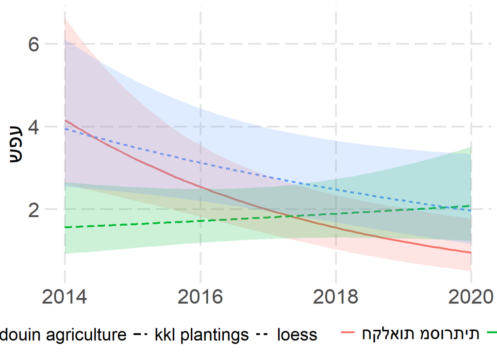

```r
# Plot the temporal trend:
loess.abnd.effect_plot <- interact_plot(model = loess.abnd.model.full.NB, partial.residuals = F, interval = T,
                                         pred = year.count, modx = habitat, data = loess, colors = "Qual1", point.alpha = 0.25,
                                         plot.points = F, jitter = c(0.2,0), int.type = 'confidence', line.colors = "black", pred.labels = 2013:2020) +
   theme_minimal() + theme(plot.title = element_text(hjust = 0.5), plot.subtitle = element_text(hjust = 0.5), legend.position = 'bottom',
                     text = element_text(family = fontname, size = fontsize), axis.text = element_text(size = fontsize - 1),
                     panel.grid.major = element_line(color = 'grey90', linetype = 5, linewidth = 1),
                     panel.grid.minor = element_blank(), panel.grid.minor.x = element_blank()) + #  scale_y_continuous(limits = c(0, 8), breaks = 0:8) +
  scale_x_continuous(breaks = loess[, sort(unique(year.count))], labels = loess[, .(year = unique(year)), keyby = year.count][, year], name = NULL) +
  scale_fill_discrete(name = NULL, labels = c(strReverse('חקלאות מסורתית'), strReverse('קציר נגר'), strReverse('לס טבעי'))) +
  scale_color_discrete(name = NULL, labels = c(strReverse('חקלאות מסורתית'), strReverse('קציר נגר'), strReverse('לס טבעי'))) +
  labs(color = NULL, fill = strReverse('בית גידול'), y = strReverse('שפע'))
loess.abnd.effect_plot # The prediction seems reasonable
```

```r
Cairo::Cairo(file = '../output/Loess abundance temporal trend interact plot.pdf', width = pdf_width, height = pdf_width*pdf_aspect_ratio,
             type = "PDF", units = "mm")
print(loess.abnd.effect_plot)
dev.off()
```

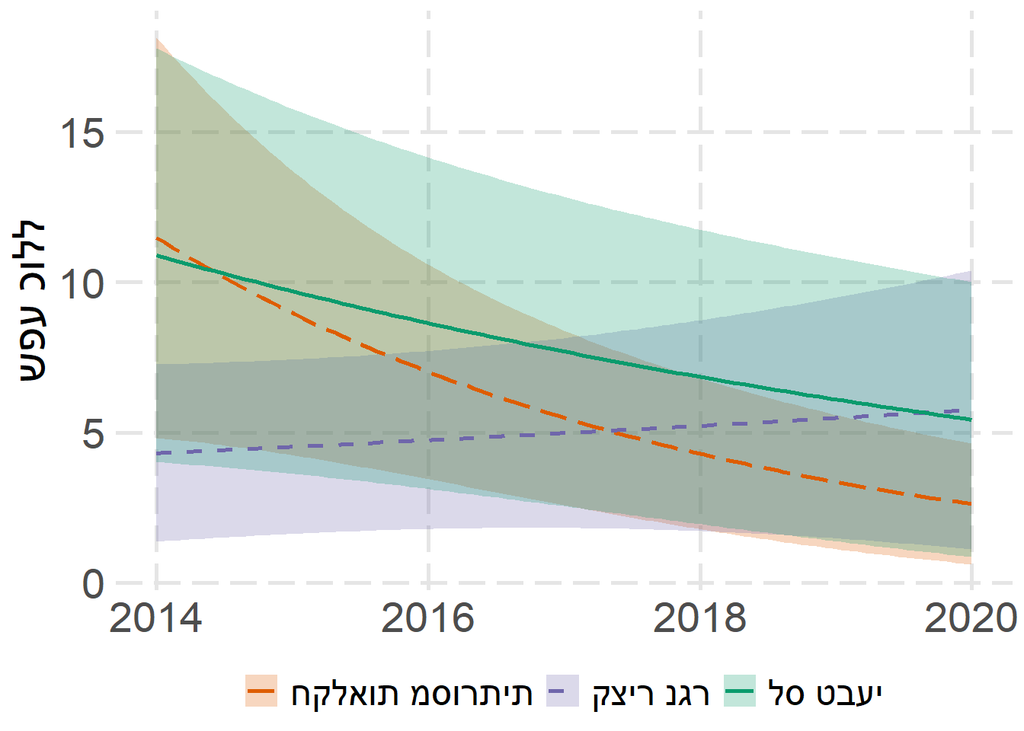

```r
loess.total.abnd.fake.effect.plot <- ggplot(data = loess.total.abnd.fit.data, aes(x = year, y = predicted.abnd, color = habitat, fill = habitat, linetype = habitat)) +
geom_ribbon(aes(x = year, ymin = predicted.abnd - 1.96*predicted.abnd.se, ymax = predicted.abnd + 1.96*predicted.abnd.se),
              alpha = 0.25, color = NA) + # geom_hline(yintercept = 0) +
  geom_line(linewidth = 1) + labs(y = strReverse('שפע כולל'), x = NULL) +
  scale_linetype_manual(name = NULL, labels = c(strReverse('חקלאות מסורתית'), strReverse('קציר נגר'), strReverse('לס טבעי')),
                          values = c('longdash', 'dashed', 'solid')) +
  scale_fill_manual(name = NULL, labels = c(strReverse('חקלאות מסורתית'), strReverse('קציר נגר'), strReverse('לס טבעי')),
                    values = c('#DE5D00', '#6F66AB','#0B9B6D')) +
  scale_color_manual(name = NULL, labels = c(strReverse('חקלאות מסורתית'), strReverse('קציר נגר'), strReverse('לס טבעי')),
                     values = c('#DE5D00', '#6F66AB', '#0B9B6D')) +
 # scale_x_date(date_labels = '%Y') +
  theme_minimal() + theme(plot.title = element_text(hjust = 0.5), plot.subtitle = element_text(hjust = 0.5), legend.position = 'bottom', text = element_text(family = fontname, size = fontsize), axis.text = element_text(size = fontsize - 1),
                          panel.grid.major = element_line(color = 'grey90', linetype = 5, linewidth = 1),
                          panel.grid.minor = element_blank(), panel.grid.minor.x = element_blank())
loess.total.abnd.fake.effect.plot
```

```r
Cairo::Cairo(file = "../output/loess total abundance fake effect plot.pdf", width = pdf_width, height = pdf_width*pdf_aspect_ratio,
             type = "PDF", units = "mm")
print(loess.total.abnd.fake.effect.plot)
dev.off()
```

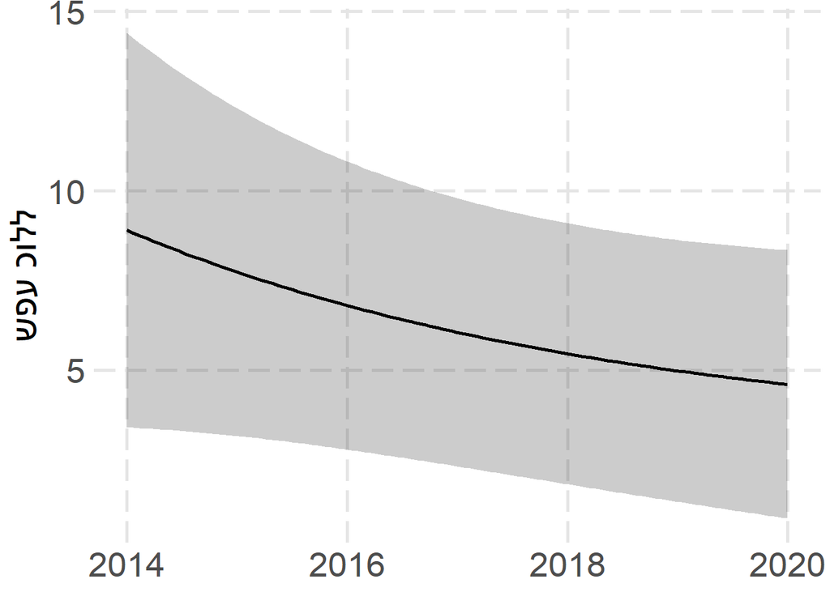

```r
loess.total.abnd.fake.effect.plot2 <- ggplot(data = loess.total.abnd.fit.data[, .(mean.abnd = mean(predicted.abnd), mean.se = mean(predicted.abnd.se)), keyby = .(year)], aes(x = year, y = mean.abnd)) +
geom_ribbon(aes(x = year, ymin = mean.abnd - 1.96*mean.se, ymax = mean.abnd + 1.96*mean.se),
              alpha = 0.25, color = NA) + # geom_hline(yintercept = 0) +
  geom_line(linewidth = 1) + labs(y = strReverse('שפע כולל'), x = NULL) +
  theme_minimal() + theme(plot.title = element_text(hjust = 0.5), plot.subtitle = element_text(hjust = 0.5), legend.position = 'bottom', text = element_text(family = fontname, size = fontsize), axis.text = element_text(size = fontsize - 1),
                          panel.grid.major = element_line(color = 'grey90', linetype = 5, linewidth = 1),
                          panel.grid.minor = element_blank(), panel.grid.minor.x = element_blank())
loess.total.abnd.fake.effect.plot2
```

```r
Cairo::Cairo(file = "../output/loess total abundance fake effect plot - overall unit.pdf", width = pdf_width, height = pdf_width*pdf_aspect_ratio,
             type = "PDF", units = "mm")
print(loess.total.abnd.fake.effect.plot2)
dev.off()
```